# Urban vs. Rural Analysis of Overdose Rates

Tejas Patel

2024-12-13

#### Introduction

Overdose fatalities have become more prevalent in some places of the United States than others due to the opioid epidemic’s devastating effects. Rural locations also have difficulties in accessing healthcare and overdose prevention services, even though most conversations focus on metropolitan places because of their large population density and infrastructure. This research examines geographical differences, temporal trends, and overdose rates in urban and rural states.

By dividing states into urban and rural regions according to population density, this approach explores the structural and geographic components of overdose outcomes. The study’s findings might contribute to a better understanding of the dynamics of the crisis and help guide effective public health measures.

#### Data and Methods

The resident population and population density for the states, regions, and country of the United States are included in this collection of data spanning many decades. To ensure that only state-level data was included, data cleaning involved eliminating rows for regions and nation-level summaries as well as rows with missing or blank values in the important columns. Commas were removed from the population and density columns to put the data in numeric format.

The dataset was then enlarged to cover every year for every state over one-year intervals in a continuous series. In order to provide seamless transitions between data points, missing values in the population and density were then filled in with newly added data using linear interpolation.

The dataset was then used to generate visualizations and a table to investigate the links between population density, overdose facilities, and fatalities per capita.

```r
#Load datasets
cdc_data <- read.csv("cdc_data.csv")
statedata <- read.csv("statedata.csv")
region <- read.csv("states.csv")
population_data <- read.csv("popdata.csv")

#Clean CDC data
cdc_clean <- cdc_data %>%
  select(-Notes, -State.Code, -UCD...Drug.Alcohol.Induced.Code) %>%
  filter(!is.na(Crude.Rate) & Crude.Rate != "Unreliable") %>%
  mutate(Crude.Rate = as.numeric(Crude.Rate)) %>%
  drop_na()

#Clean state data for overdose prevention facilities
state_clean <- statedata %>%
  filter(INDICATOR == "SA_fac") %>%
  select(STATE, YEAR, VALUE)

#Filter and interpolate missing population data
population_clean <- population_data %>%
  select(-c(5, 7, 8, 9, 10))
population_clean <- population_clean %>%
  #Convert to numeric and remove commas
  mutate(
    Resident.Population = as.numeric(gsub(",", "", Resident.Population)),
    Resident.Population.Density = as.numeric(gsub(",", "", Resident.Population.Density))
  ) %>%
  #Exclude non-state rows
  filter(Geography.Type == "State") %>%
  #Expand data to include all years in sequence for each state
  group_by(Name) %>%
  complete(Year = full_seq(Year, 1)) %>%
  #Interpolate data for the expanded years
  mutate(
    Resident.Population = zoo::na.approx(Resident.Population, na.rm = FALSE),
    Resident.Population.Density = zoo::na.approx(Resident.Population.Density, na.rm = FALSE)
  ) %>%
  ungroup()


#Filter datasets to shared years
cdc_clean <- cdc_clean %>% filter(Year >= 2004 & Year <= 2019)
population_clean <- population_clean %>% filter(Year >= 2004 & Year <= 2019)

#Merge datasets
merged_data <- cdc_clean %>%
  inner_join(state_clean, by = c("State" = "STATE", "Year" = "YEAR")) %>%
  inner_join(region, by = c("State" = "State")) %>%
  inner_join(population_clean, by = c("State" = "Name", "Year"))
```

#### Classifying Urban and Rural States

Using the interpolated population density data, states were classified as urban or rural. The following table summarizes some of the features of this categorization, including average population density, deaths per capita, total facilities, and total deaths.

```r
#Classify states as Urban or Rural based on population density
merged_data <- merged_data %>%
  mutate(Urban_Rural = ifelse(Resident.Population.Density > 100, "Urban", "Rural"))

#Summarize Urban vs. Rural characteristics
urban_rural_summary <- merged_data %>%
  group_by(Urban_Rural) %>%
  summarize(
    Avg_Population_Density = mean(Resident.Population.Density, na.rm = TRUE),
    Avg_Deaths_Per_Capita = mean(Deaths / Resident.Population, na.rm = TRUE),
    Total_Facilities = sum(VALUE, na.rm = TRUE),
    Total_Deaths = sum(Deaths, na.rm = TRUE)
  )

#Display summary table
urban_rural_summary %>%
  kable("html", caption = "Urban vs. Rural Characteristics Summary") %>%
  kable_styling(full_width = FALSE, bootstrap_options = c("striped", "hover"))
```

Urban vs. Rural Characteristics Summary

| Urban_Rural | Avg_Population_Density | Avg_Deaths_Per_Capita | Total_Facilities | Total_Deaths |
| --- | --- | --- | --- | --- |
| Rural | 43.89829 | 0.0001502 | 109244 | 383418 |
| Urban | 726.43269 | 0.0001760 | 260380 | 1186668 |

Urban states have substantially larger population densities, more overdose prevention services, and higher mortality rates per capita than rural areas. These disparities may also represent systemic imbalances in resource allocation and population health outcomes.

#### Temporal Trends in Overdose Rates

Overdose rates were analyzed over time for urban and rural states. The following line plot illustrates the average crude overdose rates per 100,000 for each classification from 2004 to 2019.

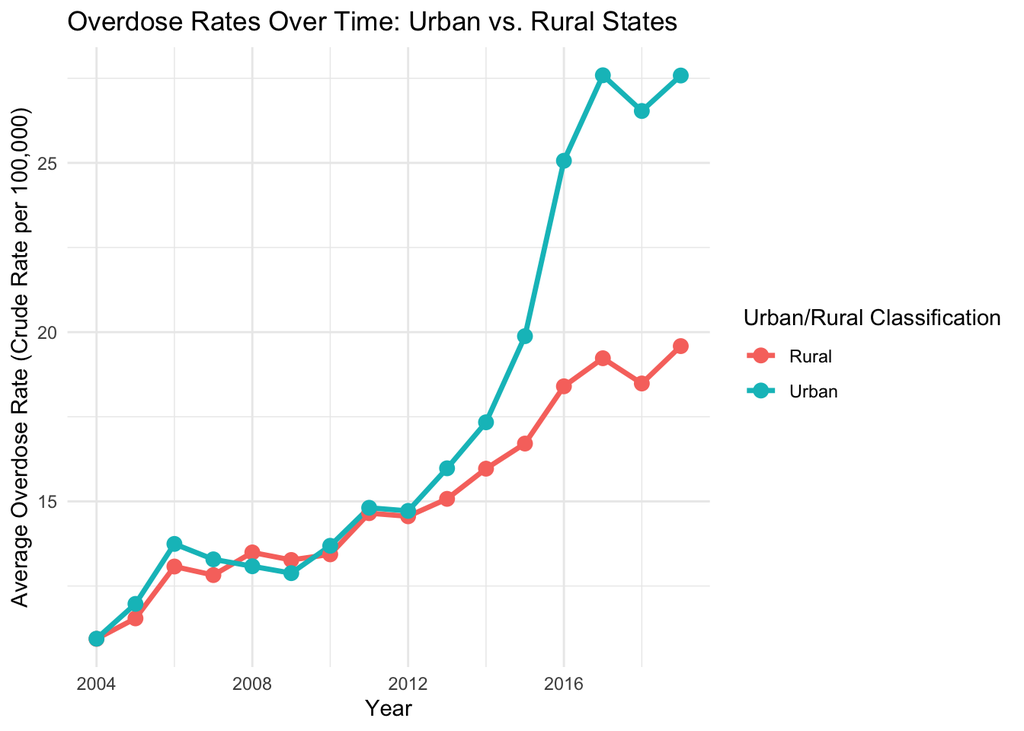

```r
#Aggregate data by Urban/Rural and Year
urban_rural_trends <- merged_data %>%
  mutate(Urban_Rural = ifelse(Resident.Population.Density > 100, "Urban", "Rural")) %>%
  group_by(Urban_Rural, Year) %>%
  summarize(
    Avg_Crude_Rate = mean(Crude.Rate, na.rm = TRUE),
    .groups = "drop"
  )

#Line plot
ggplot(urban_rural_trends, aes(x = Year, y = Avg_Crude_Rate, color = Urban_Rural, group = Urban_Rural)) +
  geom_line(size = 1.2) +
  geom_point(size = 3) +
  theme_minimal() +
  labs(
    title = "Overdose Rates Over Time: Urban vs. Rural States",
    x = "Year",
    y = "Average Overdose Rate (Crude Rate per 100,000)",
    color = "Urban/Rural Classification"
  )
```

#### Regional Comparisons

To study regional differences, per capita overdose deaths were compared among classes of urban/rural classifications for each U.S. Census region. The figure below depicts a bar chart for comparison of average deaths per capita between regions.

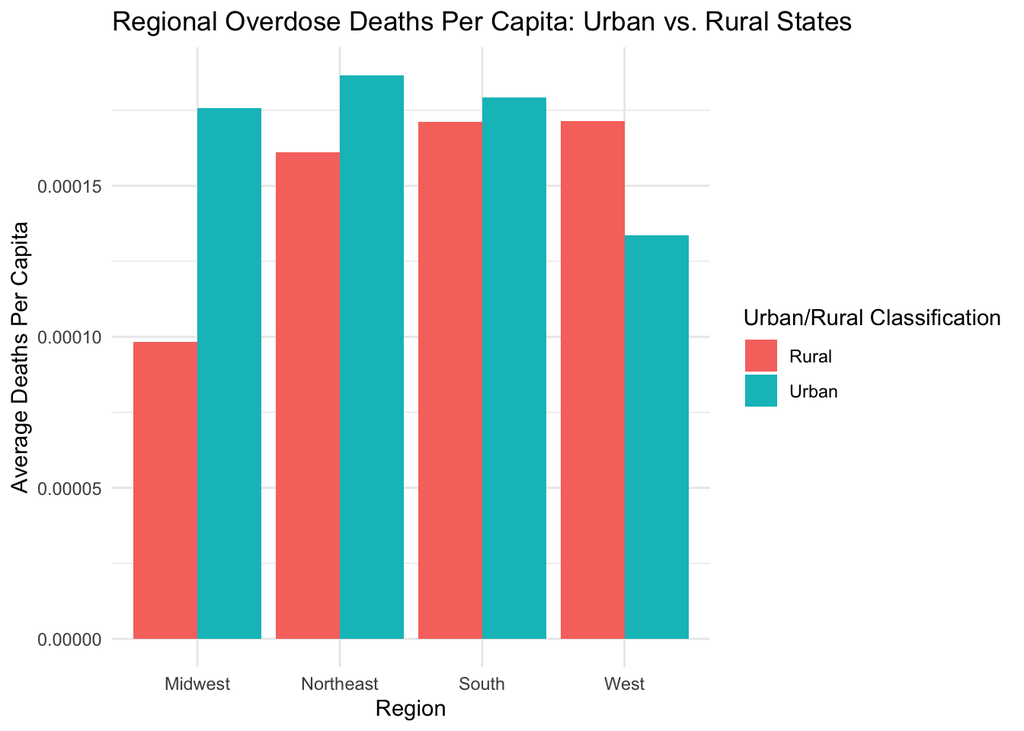

```r
#Regional breakdown of Urban vs. Rural rates
regional_comparison <- merged_data %>%
  group_by(Region, Urban_Rural) %>%
  summarize(
    Avg_Deaths_Per_Capita = mean(Deaths / Resident.Population, na.rm = TRUE),
    Total_Facilities = sum(VALUE, na.rm = TRUE),
    Total_Deaths = sum(Deaths, na.rm = TRUE),
    .groups = "drop"
  )

#Bar plot for regional differences
ggplot(regional_comparison, aes(x = Region, y = Avg_Deaths_Per_Capita, fill = Urban_Rural)) +
  geom_bar(stat = "identity", position = "dodge") +
  theme_minimal() +
  labs(
    title = "Regional Overdose Deaths Per Capita: Urban vs. Rural States",
    x = "Region",
    y = "Average Deaths Per Capita",
    fill = "Urban/Rural Classification"
  )
```

The urban states of the Midwest, Northeast, and South have higher average deaths per capita compared to their rural counterparts, but the Midwest presents the greatest disparity. The rural West states have slightly higher average deaths per capita than the urban West states, while the urban West states report higher total deaths across all years.

#### Overdose Facilities Access vs Deaths Per Capita by Urbanization Type

The following scatterplot investigates the relationship between overdose prevention facilities per capita and overdose deaths per capita across urban and rural states. The goal is to visually assess whether access to facilities correlates with reduced deaths and to highlight disparities between urban and rural areas.

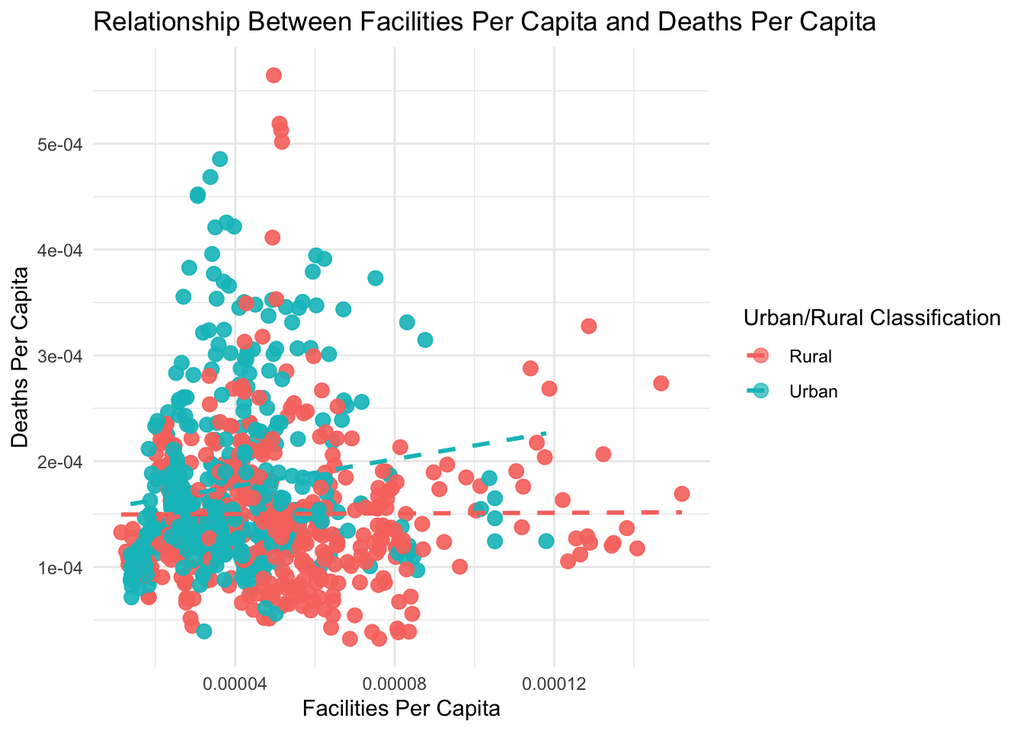

```r
#Scatter plot: Facilities per capita vs. Deaths per capita
scatter_data <- merged_data %>%
  mutate(Facilities_Per_Capita = VALUE / Resident.Population,
         Deaths_Per_Capita = Deaths / Resident.Population)

ggplot(scatter_data, aes(x = Facilities_Per_Capita, y = Deaths_Per_Capita, color = Urban_Rural)) +
  geom_point(alpha = 0.7, size = 3) +
  geom_smooth(method = "lm", se = FALSE, linetype = "dashed") +
  theme_minimal() +
  labs(
    title = "Relationship Between Facilities Per Capita and Deaths Per Capita",
    x = "Facilities Per Capita",
    y = "Deaths Per Capita",
    color = "Urban/Rural Classification"
  )
```

There is a slight positive correlation between facilities per capita and deaths per capita, which might indicate clustering of resources in high-need areas in urban states. In rural states, no such correlation exists, even though the facilities per capita are higher, which may be indicative of barriers to effective utilization.

#### Discussion / Conclusion

Urban states in the Midwest, Northeast, and South have persistently greater average deaths per capita than rural states. The Midwest has the greatest urban-rural split, with urban Midwest states reporting nearly twice as many deaths per capita as rural Midwest states. In the West, rural states have somewhat higher average deaths per capita, but urban West states have a higher total mortality rate, illustrating the influence of population size in these trends.

The association between overdose prevention facilities and deaths per capita highlights urban-rural disparities. There is a minor positive association between urban states, indicating that facilities are more likely to be located in high-need areas. Rural states show no correlation, despite having more services per capita. This disparity indicates that structural hurdles in rural areas, such as geographic isolation and restricted healthcare access, may impede the effectiveness of these resources. Additionally, the lack of correlation between facilities and deaths per capita in rural areas suggests the need to evaluate the effectiveness of resource distribution.

These findings underline the importance of equitable, geographically customized interventions. Rural states demand more access to healthcare and overdose prevention facilities, whereas Urban states may benefit from addressing systemic issues, including over-prescription and socioeconomic determinants of health. Future research should explore the interplay of socioeconomic factors, healthcare infrastructure, and regional variations to inform more effective, equitable solutions. By addressing the unique challenges of urban and rural communities, policymakers can develop strategies to mitigate the devastating effects of the opioid epidemic and promote equitable health outcomes nationwide.